# CellAssign: Automatic cell annotation

https://irrationone.github.io/cellassign/articles/introduction-to-cellassign.html

## Overview

- CellAssign はscRNA-seqデータの各細胞を、マーカー遺伝子の情報に基づいて既知の細胞型に割り当てることができます。
- 他のscRNA-seqデータから細胞タイプを割り当てる方法とは異なり、CellAssignnはラベリングされたシングルセルまたは精製バルク発現データを必要としません。CellAssignは、各細胞タイプのマーカー遺伝子を知る必要があるだけです。

```r
tensorflow::tf_config()
```

```
TensorFlow v2.2.0 (/opt/conda/lib/python3.7/site-packages/tensorflow)
Python v3.7 (/opt/conda/bin/python3)
```

```r
options(warn=-1)

library(SingleCellExperiment)
library(cellassign)
```

ここでは `SingleCellExperiment` オブジェクトを入力にします。 consisting of 200 genes and 500 cells

```r
data(example_sce)
print(example_sce)
```

```
class: SingleCellExperiment
dim: 200 500
metadata(20): params params ... params params
assays(6): BatchCellMeans BaseCellMeans ... TrueCounts counts
rownames(200): Gene1 Gene2 ... Gene199 Gene200
rowData names(6): Gene BaseGeneMean ... DEFacGroup1 DEFacGroup2
colnames(500): Cell1 Cell2 ... Cell499 Cell500
colData names(5): Cell Batch Group ExpLibSize EM_group
reducedDimNames(0):
altExpNames(0):
```

The true cell types are annotated for convenience in the Group slot of the SingleCellExperiment:

```r
print(head(example_sce$Group))
```

```
[1] "Group1" "Group2" "Group2" "Group1" "Group1" "Group1"
```

Also provided is an example gene-by-cell-type binary matrix, whose entries are 1 if a gene is a marker for a given cell type and 0 otherwise:

```r
data(example_marker_mat)
print(example_marker_mat)
```

```
       Group1 Group2
Gene1       1      0
Gene2       0      1
Gene3       1      0
Gene4       1      0
Gene5       1      0
Gene6       0      1
Gene7       0      1
Gene8       0      1
Gene9       0      1
Gene10      1      0
```

さらに、各セルの size factorsが必要です。これらは `sizeFactors(example_sce)` に格納されています - データについては `scran` パッケージの `computeSumFactors` 関数を使用して計算することをお勧めします。

注意: cellassignへの入力のためにマーカーにサブセットする前に、遺伝子のフルセットを使用してサイズ因子を計算することを強くお勧めします。

```r
s <- sizeFactors(example_sce)
```

- 次に、上記の情報を入力し、`cellassign()`関数を用いてcellassignを呼び出します。
- マーカー遺伝子のみの遺伝子発現データをcellassignへの入力として使用することが重要である。
- ここでは、入力`SingleCellExperiment`を行名（遺伝子名）を使用してをサブセットにすることでこれを行います。
- これはまた、遺伝子発現データ中の遺伝子の順序がマーカーマトリックス中の遺伝子の順序と一致することを保証する。

```r
fit <- cellassign(exprs_obj = example_sce[rownames(example_marker_mat),],
                  marker_gene_info = example_marker_mat,
                  s = s,
                  learning_rate = 1e-2,
                  shrinkage = TRUE,
                  verbose = FALSE)
print(fit)
```

```
A cellassign fit for 500 cells, 10 genes, 2 cell types with 0 covariates
            To access cell types, call celltypes(x)
            To access cell type probabilities, call cellprobs(x)
```

We can access the maximum likelihood estimates (MLE) of cell type using the celltypes function:

```r
print(head(celltypes(fit)))
```

```
[1] "Group1" "Group2" "Group2" "Group1" "Group1" "Group1"
```

and all MLE parameters using mleparams:

```r
print(str(mleparams(fit)))
```

```
List of 9
 $ delta  : num [1:10, 1:2] 2.32 0 2.5 2.74 2.84 ...
  ..- attr(*, "dimnames")=List of 2
  .. ..$ : chr [1:10] "Gene1" "Gene2" "Gene3" "Gene4" ...
  .. ..$ : chr [1:2] "Group1" "Group2"
 $ beta   : num [1:10, 1] 0.488 -0.141 -1.016 1.329 1.518 ...
  ..- attr(*, "dimnames")=List of 2
  .. ..$ : chr [1:10] "Gene1" "Gene2" "Gene3" "Gene4" ...
  .. ..$ : NULL
 $ phi    : num [1:500, 1:10, 1:2] 1.91 1.91 1.9 1.9 1.9 ...
 $ gamma  : num [1:500, 1:2] 1.00 5.59e-140 1.16e-42 1.00 1.00 ...
  ..- attr(*, "dimnames")=List of 2
  .. ..$ : NULL
  .. ..$ : chr [1:2] "Group1" "Group2"
 $ mu     : num [1:500, 1:10, 1:2] 22.6 80.9 11.5 15.5 15.8 ...
 $ a      : num [1:10(1d)] 1.05 1.1 1.16 1.22 1.29 ...
 $ theta  : num [1:2(1d)] 0.472 0.528
  ..- attr(*, "dimnames")=List of 1
  .. ..$ : chr [1:2] "Group1" "Group2"
 $ ld_mean: num 0.991
 $ ld_var : num 0.829
NULL
```

We can also visualize the probabilities of assignment using the cellprobs function that returns a probability matrix for each cell and cell type:

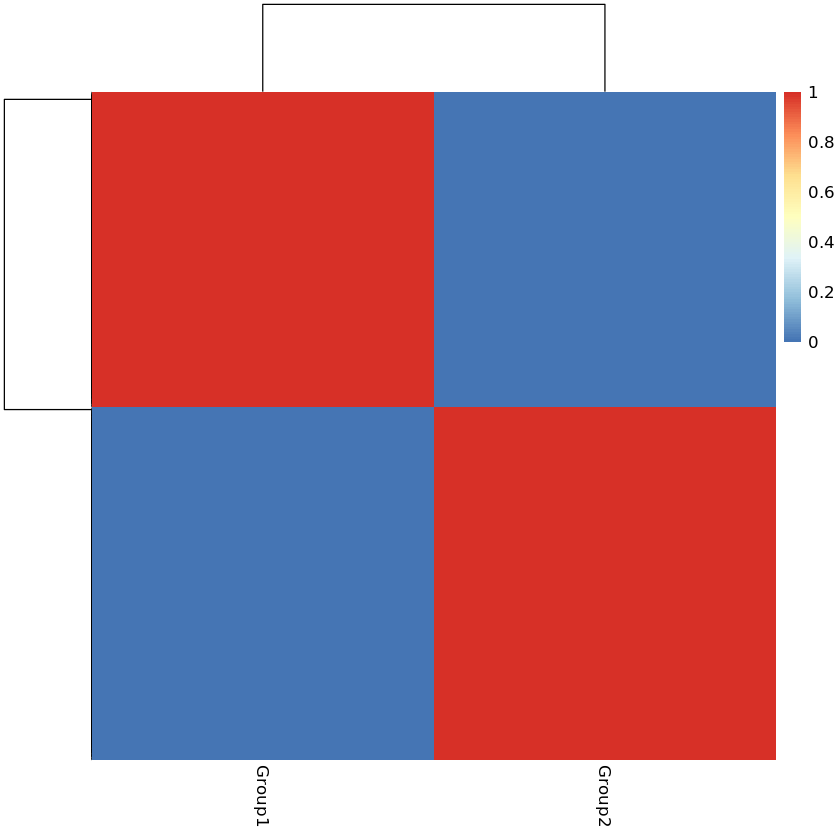

```r
pheatmap::pheatmap(cellprobs(fit))
```

```r
# Finally, since this is simulated data we can check the concordance with the true group values:

print(table(example_sce$Group, celltypes(fit)))
```

```
         Group1 Group2
  Group1    236      0
  Group2      0    264
```

## Example set of markers for tumour microenvironment

ヒト腫瘍微小環境における一般的な細胞タイプのセルアサインパッケージには、マーカーの例が含まれています。ユーザーは以下のことに注意する必要があります

- このセットは例として提供されているものであり、研究者は自分たちの使用のためにマーカー遺伝子セットを導出することを推奨する。
- CellAssignのワークフローは通常、すべてのマーカーが発現データに発現していることを確認し、存在しないと思われる細胞タイプを入力マーカーマトリックスから削除するなど、反復的に行われます。

These can be accessed by calling

```r
data(example_TME_markers)
```

Note that this is a list of two marker lists:

```r
names(example_TME_markers)
```

1. 'symbol'

2. 'ensembl'

```r
lapply(head(example_TME_markers$symbol, n = 4), head, n = 4)
```

**$`B cells`**

1. 'VIM'

2. 'MS4A1'

3. 'CD79A'

4. 'PTPRC'

**$`T cells`**

1. 'VIM'

2. 'CD2'

3. 'CD3D'

4. 'CD3E'

**$`Cytotoxic T cells`**

1. 'VIM'

2. 'CD2'

3. 'CD3D'

4. 'CD3E'

**$`Monocyte/Macrophage`**

1. 'VIM'

2. 'CD14'

3. 'FCGR3A'

4. 'CD33'

and `ensembl` contains the equivalent ensembl gene ids:

```r
lapply(head(example_TME_markers$ensembl, n = 4), head, n = 4)
```

**$`B cells`**

**VIM**

'ENSG00000026025'

**MS4A1**

'ENSG00000156738'

**CD79A**

'ENSG00000105369'

**PTPRC**

'ENSG00000081237'

**$`T cells`**

**VIM**

'ENSG00000026025'

**CD2**

'ENSG00000116824'

**CD3D**

'ENSG00000167286'

**CD3E**

'ENSG00000198851'

**$`Cytotoxic T cells`**

**VIM**

'ENSG00000026025'

**CD2**

'ENSG00000116824'

**CD3D**

'ENSG00000167286'

**CD3E**

'ENSG00000198851'

**$`Monocyte/Macrophage`**

**VIM**

'ENSG00000026025'

**CD14**

'ENSG00000170458'

**FCGR3A**

'ENSG00000203747'

**CD33**

'ENSG00000105383'

To use these with `cellassign` we can turn them into the binary marker by cell type matrix:

```r
marker_mat <- marker_list_to_mat(example_TME_markers$ensembl)

marker_mat[1:3, 1:3]
```

A matrix: 3 × 3 of type dbl

|  | B cells | T cells | Cytotoxic T cells |
| --- | --- | --- | --- |
| ENSG00000010610 | 0 | 1 | 0 |
| ENSG00000026025 | 1 | 1 | 1 |
| ENSG00000039068 | 0 | 0 | 0 |

**Important**: the single cell experiment or input gene expression matrix should be subset accordingly to match the rows of the marker input matrix, e.g. if sce is a SingleCellExperiment with ensembl IDs as rownames then call

```r
sce_marker <- sce[intersect(rownames(marker_mat), rownames(sce)),]
```

[output not shown]

Note that the rows in the single cell experiment or gene expression matrix should be ordered identically to those in the marker input matrix.

You can the proceed using cellassign as before.

## Advanced usage

### Options for a `cellassign()` call

There are several options to a call to cellassign that can alter the results:

- min_delta: the minimum log-fold change in expression above which a genemust be over-expressed in the cells of which it is a marker compared to all others
- X: a covariate matrix, see section below
- shrinkage: whether to impose a hierarchical prior on the values of delta (cell type specific increase in expression of marker genes)